# Association Between Vitamin D Levels and Depression Among U.S. Adults: NHANES 2021-2023

Bisrat Bekele

2025-11-29

# 1. Install packages and open libraries

```r
# Install pacman if not already installed
if (!require("pacman")) install.packages("pacman")
```

```r
# Load necessary packages
pacman::p_load(
  ggplot2,
  car,
  odds.n.ends,
  dplyr,
  tidyr,
  haven,
  table1,
  DiagrammeR,
  rsvg
)
```

# 2. Import NHANES 2021-2023 Data

```r
github_base <- "https://raw.githubusercontent.com/Bisratbekele/ADA-Final-Assignment/master/"

DEMO_L <- read_xpt(paste0(github_base, "DEMO_L.xpt"))
VID_L  <- read_xpt(paste0(github_base, "VID_L.xpt"))
DPQ_L  <- read_xpt(paste0(github_base, "DPQ_L.xpt"))
BMX_L  <- read_xpt(paste0(github_base, "BMX_L.xpt"))
SMQ_L  <- read_xpt(paste0(github_base, "SMQ_L.xpt"))

cat("DEMO_L dimensions:", dim(DEMO_L), "\n")
```

```
## DEMO_L dimensions: 11933 27
```

```r
cat("VID_L dimensions:",  dim(VID_L),  "\n")
```

```
## VID_L dimensions: 8727 10
```

```r
cat("DPQ_L dimensions:",  dim(DPQ_L),  "\n")
```

```
## DPQ_L dimensions: 6337 11
```

```r
cat("BMX_L dimensions:",  dim(BMX_L),  "\n")
```

```
## BMX_L dimensions: 8860 22
```

```r
cat("SMQ_L dimensions:",  dim(SMQ_L),  "\n")
```

```
## SMQ_L dimensions: 9015 9
```

# 3. Data Management

## 3a. Merge datasets by SEQN

```r
nhanes_data <- DEMO_L %>%
  left_join(VID_L, by = "SEQN") %>%
  left_join(DPQ_L, by = "SEQN") %>%
  left_join(BMX_L, by = "SEQN") %>%
  left_join(SMQ_L, by = "SEQN")

# Check merged
cat("Merged dataset dimensions:", dim(nhanes_data), "\n")
```

```
## Merged dataset dimensions: 11933 75
```

## 3b. Create PHQ-9 depression score

```r
nhanes_data <- nhanes_data %>%
  mutate(
    # Sum PHQ-9 items (DPQ010 - DPQ090)
    phq9_total = rowSums(select(., starts_with("DPQ0")), na.rm = FALSE),

    # Create binary depression variable (PHQ-9 ≥ 10 = moderate to severe depression)
    depression_binary = case_when(
      phq9_total >= 10 ~ 1,
      phq9_total < 10 ~ 0
    )
  )

# Convert to factor
nhanes_data$depression_binary <- factor(
  nhanes_data$depression_binary,
  levels = c(0, 1),
  labels = c("No Depression", "Depression")
)

# Check distribution
table(nhanes_data$depression_binary, useNA = "always")
```

```
##
## No Depression    Depression          <NA>
##          4745           761          6427
```

## 3c. Create Vitamin D categorical variable

```r
# Categorical Total Vitamin D variable based on clinical cutoffs
# Deficient: <50 nmol/L
# Insufficient: 50-74 nmol/L
# Sufficient: ≥75 nmol/L

nhanes_data <- nhanes_data %>%
  mutate(
    vitd_category = case_when(
      LBXVIDMS < 50 ~ "Deficient",
      LBXVIDMS >= 50 & LBXVIDMS < 75 ~ "Insufficient",
      LBXVIDMS >= 75 ~ "Sufficient"
    )
  )

# Convert to factor
nhanes_data$vitd_category <- factor(
  nhanes_data$vitd_category,
  levels = c("Sufficient", "Insufficient", "Deficient")
)

# Check distribution
table(nhanes_data$vitd_category, useNA = "always")
```

```
##
##   Sufficient Insufficient    Deficient         <NA>
##         3407         2327         1573         4626
```

## 3d. Recode demographic and health variables

```r
nhanes_data <- nhanes_data %>%
  mutate(
    # Age groups
    age_cat = case_when(
      RIDAGEYR >= 18 & RIDAGEYR < 30 ~ "18-29",
      RIDAGEYR >= 30 & RIDAGEYR < 40 ~ "30-39",
      RIDAGEYR >= 40 & RIDAGEYR < 50 ~ "40-49",
      RIDAGEYR >= 50 & RIDAGEYR < 60 ~ "50-59",
      RIDAGEYR >= 60 & RIDAGEYR < 70 ~ "60-69",
      RIDAGEYR >= 70 ~ "70+"
    ),

    # Sex (RIAGENDR: 1=Male, 2=Female)
    sex = case_when(
      RIAGENDR == 1 ~ "Male",
      RIAGENDR == 2 ~ "Female"
    ),

    # Race/Ethnicity (RIDRETH3)
    race_ethnicity = case_when(
      RIDRETH3 == 1 ~ "Mexican American",
      RIDRETH3 == 2 ~ "Other Hispanic",
      RIDRETH3 == 3 ~ "Non-Hispanic White",
      RIDRETH3 == 4 ~ "Non-Hispanic Black",
      RIDRETH3 == 6 ~ "Non-Hispanic Asian",
      RIDRETH3 == 7 ~ "Other/Multiracial"
    ),

    # Education (DMDEDUC2: for adults 20+)
    education = case_when(
      DMDEDUC2 == 1 ~ "Less than 9th grade",
      DMDEDUC2 == 2 ~ "9-11th grade",
      DMDEDUC2 == 3 ~ "High school/GED",
      DMDEDUC2 == 4 ~ "Some college/AA",
      DMDEDUC2 == 5 ~ "College graduate or above"
    ),

    # Smoking status (SMQ020: Have you smoked at least 100 cigarettes?)
    smoking_status = case_when(
      SMQ020 == 1 ~ "Ever smoker",
      SMQ020 == 2 ~ "Never smoker"
    )
  )

# Convert categorical variables to factors
nhanes_data$age_cat <- factor(nhanes_data$age_cat,
                              levels = c("18-29", "30-39", "40-49", "50-59", "60-69", "70+"))
nhanes_data$sex <- factor(nhanes_data$sex, levels = c("Male", "Female"))
nhanes_data$race_ethnicity <- factor(nhanes_data$race_ethnicity)
nhanes_data$education <- factor(nhanes_data$education,
                                levels = c("Less than 9th grade", "9-11th grade",
                                          "High school/GED", "Some college/AA",
                                          "College graduate or above"))
nhanes_data$smoking_status <- factor(nhanes_data$smoking_status,
                                    levels = c("Never smoker", "Ever smoker"))
```

## 3e. Select variables for analysis

```r
# variables needed for this analysis
analysis_data <- nhanes_data %>%
  select(
    SEQN,                    # Participant ID
    LBXVIDMS,                # Serum Vitamin D (continuous)
    vitd_category,           # Vitamin D categories
    phq9_total,              # PHQ-9 total score
    depression_binary,       # Depression outcome
    RIDAGEYR,                # Age (continuous)
    age_cat,                 # Age categories
    sex,                     # Sex
    race_ethnicity,          # Race/Ethnicity
    BMXBMI,                  # BMI
    education,               # Education
    INDFMPIR,                # Poverty Income Ratio
    smoking_status           # Smoking status
  )
glimpse(analysis_data)
```

```
## Rows: 11,933
## Columns: 13
## $ SEQN              <dbl> 130378, 130379, 130380, 130381, 130382, 130383, 1303…
## $ LBXVIDMS          <dbl> 58.9, 60.5, 39.4, NA, NA, NA, NA, NA, 96.9, 26.7, NA…
## $ vitd_category     <fct> Insufficient, Insufficient, Deficient, NA, NA, NA, N…
## $ phq9_total        <dbl> NA, 1, 2, NA, NA, NA, NA, NA, 1, 0, NA, 0, NA, 24, 1…
## $ depression_binary <fct> NA, No Depression, No Depression, NA, NA, NA, NA, NA…
## $ RIDAGEYR          <dbl> 43, 66, 44, 5, 2, 3, 43, 65, 34, 68, 27, 59, 31, 33,…
## $ age_cat           <fct> 40-49, 60-69, 40-49, NA, NA, NA, 40-49, 60-69, 30-39…
## $ sex               <fct> Male, Male, Female, Female, Male, Female, Male, Fema…
## $ race_ethnicity    <fct> Non-Hispanic Asian, Non-Hispanic White, Other Hispan…
## $ BMXBMI            <dbl> 27.0, 33.5, 29.7, 23.8, NA, NA, NA, NA, 30.2, 42.6, …
## $ education         <fct> College graduate or above, College graduate or above…
## $ INDFMPIR          <dbl> 5.00, 5.00, 1.41, 1.53, 3.60, NA, 0.63, 5.00, 1.33, …
## $ smoking_status    <fct> Ever smoker, Ever smoker, Never smoker, NA, NA, NA, …
```

# 4. Examine variables for missing data

```r
# Examine categorical variables
table(analysis_data$depression_binary, useNA = "always")
```

```
##
## No Depression    Depression          <NA>
##          4745           761          6427
```

```r
table(analysis_data$vitd_category, useNA = "always")
```

```
##
##   Sufficient Insufficient    Deficient         <NA>
##         3407         2327         1573         4626
```

```r
table(analysis_data$sex, useNA = "always")
```

```
##
##   Male Female   <NA>
##   5575   6358      0
```

```r
table(analysis_data$age_cat, useNA = "always")
```

```
##
## 18-29 30-39 40-49 50-59 60-69   70+  <NA>
##  1248  1180  1042  1179  1765  1739  3780
```

```r
table(analysis_data$race_ethnicity, useNA = "always")
```

```
##
##   Mexican American Non-Hispanic Asian Non-Hispanic Black Non-Hispanic White
##               1117                681               1597               6217
##     Other Hispanic  Other/Multiracial               <NA>
##               1373                948                  0
```

```r
table(analysis_data$education, useNA = "always")
```

```
##
##       Less than 9th grade              9-11th grade           High school/GED
##                       373                       666                      1749
##           Some college/AA College graduate or above                      <NA>
##                      2370                      2625                      4150
```

```r
table(analysis_data$smoking_status, useNA = "always")
```

```
##
## Never smoker  Ever smoker         <NA>
##         4878         3243         3812
```

```r
# Examine continuous variables
summary(analysis_data$LBXVIDMS)      # Vitamin D
```

```
##    Min. 1st Qu.  Median    Mean 3rd Qu.    Max.    NA's
##    7.97   53.00   72.00   77.46   95.65  424.00    4626
```

```r
summary(analysis_data$RIDAGEYR)      # Age
```

```
##    Min. 1st Qu.  Median    Mean 3rd Qu.    Max.
##    0.00   13.00   37.00   38.32   62.00   80.00
```

```r
summary(analysis_data$BMXBMI)        # BMI
```

```
##    Min. 1st Qu.  Median    Mean 3rd Qu.    Max.    NA's
##   11.10   21.60   26.40   27.25   31.70   74.80    3462
```

```r
summary(analysis_data$phq9_total)    # PHQ-9 score
```

```
##    Min. 1st Qu.  Median    Mean 3rd Qu.    Max.    NA's
##   0.000   1.000   3.000   4.244   6.000  51.000    6427
```

```r
summary(analysis_data$INDFMPIR)      # Income-to-poverty ratio
```

```
##    Min. 1st Qu.  Median    Mean 3rd Qu.    Max.    NA's
##   0.000   1.180   2.500   2.708   4.500   5.000    2041
```

# 5. Check classification of depression variable

```r
table(analysis_data$depression_binary,
      analysis_data$phq9_total >= 10,
      useNA = "always")
```

```
##
##                 FALSE TRUE <NA>
##   No Depression  4745    0    0
##   Depression        0  761    0
##   <NA>              0    0 6427
```

# 6. Descriptive visualization: Vitamin D levels by depression status

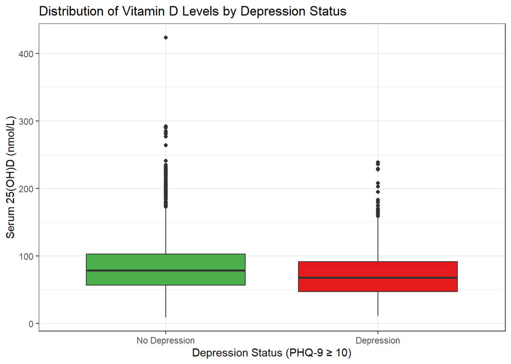

```r
# Box plot: Vitamin D levels by depression status
ggplot(data = analysis_data %>% filter(!is.na(depression_binary))) +
  geom_boxplot(aes(x = depression_binary, y = LBXVIDMS, fill = depression_binary)) +
  theme_bw() +
  xlab("Depression Status (PHQ-9 ≥ 10)") +
  ylab("Serum 25(OH)D (nmol/L)") +
  ggtitle("Distribution of Vitamin D Levels by Depression Status") +
  scale_fill_manual(values = c("#4DAF4A", "#E41A1C")) +
  theme(legend.position = "none")
```

# 7. Create exclusion datasets step-by-step (following class exercise pattern)

## 7a. Drop observations with age <18 years

```r
ex1 <- analysis_data %>%
  filter(RIDAGEYR >= 18)

cat("After excluding age <18:", nrow(ex1), "observations\n")
```

```
## After excluding age <18: 8153 observations
```

## 7b. Drop observations with missing vitamin D data

```r
ex2 <- ex1 %>%
  drop_na(LBXVIDMS)

cat("After excluding missing vitamin D:", nrow(ex2), "observations\n")
```

```
## After excluding missing vitamin D: 5824 observations
```

## 7c. Drop observations with missing PHQ-9 data

```r
ex3 <- ex2 %>%
  drop_na(depression_binary)

cat("After excluding missing PHQ-9:", nrow(ex3), "observations\n")
```

```
## After excluding missing PHQ-9: 5089 observations
```

## 7d. Drop observations with missing covariates

```r
ex4 <- ex3 %>%
  drop_na(sex, race_ethnicity, BMXBMI, education, INDFMPIR, smoking_status)

cat("After excluding missing covariates:", nrow(ex4), "observations\n")
```

```
## After excluding missing covariates: 4262 observations
```

## 7e. Create final analytic dataset

```r
analysis_complete <- ex4

cat("\nFINAL ANALYTIC SAMPLE:", nrow(analysis_complete), "observations\n")
```

```
##
## FINAL ANALYTIC SAMPLE: 4262 observations
```

# 8. Test linearity assumption for continuous predictors

```r
# Testing linearity assumption for Vitamin D using Box-Tidwell technique
analysis_complete$vitd_times_log_vitd <- analysis_complete$LBXVIDMS * log(analysis_complete$LBXVIDMS)

model_linearity_vitd <- glm(
  depression_binary ~ LBXVIDMS + vitd_times_log_vitd,
  data = analysis_complete,
  family = "binomial"
)

summary(model_linearity_vitd)
```

```
##
## Call:
## glm(formula = depression_binary ~ LBXVIDMS + vitd_times_log_vitd,
##     family = "binomial", data = analysis_complete)
##
## Coefficients:
##                      Estimate Std. Error z value Pr(>|z|)
## (Intercept)         -0.434505   0.274972  -1.580 0.114066
## LBXVIDMS            -0.071619   0.017669  -4.053 5.05e-05 ***
## vitd_times_log_vitd  0.011811   0.003211   3.679 0.000235 ***
## ---
## Signif. codes:  0 '***' 0.001 '**' 0.01 '*' 0.05 '.' 0.1 ' ' 1
##
## (Dispersion parameter for binomial family taken to be 1)
##
##     Null deviance: 3262.8  on 4261  degrees of freedom
## Residual deviance: 3220.3  on 4259  degrees of freedom
## AIC: 3226.3
##
## Number of Fisher Scoring iterations: 4
```

```r
# Testing linearity assumption for Age
analysis_complete$age_times_log_age <- analysis_complete$RIDAGEYR * log(analysis_complete$RIDAGEYR)

model_linearity_age <- glm(
  depression_binary ~ RIDAGEYR + age_times_log_age,
  data = analysis_complete,
  family = "binomial"
)

summary(model_linearity_age)
```

```
##
## Call:
## glm(formula = depression_binary ~ RIDAGEYR + age_times_log_age,
##     family = "binomial", data = analysis_complete)
##
## Coefficients:
##                    Estimate Std. Error z value Pr(>|z|)
## (Intercept)       -0.619573   0.753968  -0.822    0.411
## RIDAGEYR          -0.058656   0.080552  -0.728    0.467
## age_times_log_age  0.008413   0.016532   0.509    0.611
##
## (Dispersion parameter for binomial family taken to be 1)
##
##     Null deviance: 3262.8  on 4261  degrees of freedom
## Residual deviance: 3219.4  on 4259  degrees of freedom
## AIC: 3225.4
##
## Number of Fisher Scoring iterations: 4
```

```r
# Testing linearity assumption for BMI
analysis_complete$bmi_times_log_bmi <- analysis_complete$BMXBMI * log(analysis_complete$BMXBMI)

model_linearity_bmi <- glm(
  depression_binary ~ BMXBMI + bmi_times_log_bmi,
  data = analysis_complete,
  family = "binomial"
)

summary(model_linearity_bmi)
```

```
##
## Call:
## glm(formula = depression_binary ~ BMXBMI + bmi_times_log_bmi,
##     family = "binomial", data = analysis_complete)
##
## Coefficients:
##                   Estimate Std. Error z value Pr(>|z|)
## (Intercept)        0.15887    1.08061   0.147  0.88312
## BMXBMI            -0.36386    0.14531  -2.504  0.01228 *
## bmi_times_log_bmi  0.08583    0.03197   2.685  0.00726 **
## ---
## Signif. codes:  0 '***' 0.001 '**' 0.01 '*' 0.05 '.' 0.1 ' ' 1
##
## (Dispersion parameter for binomial family taken to be 1)
##
##     Null deviance: 3262.8  on 4261  degrees of freedom
## Residual deviance: 3237.8  on 4259  degrees of freedom
## AIC: 3243.8
##
## Number of Fisher Scoring iterations: 4
```

# Box–Tidwell tests indicated non-linearity for vitamin D and BMI but not for age, so I will model vitamin D and BMI using categorical variables while keeping age as a continuous predictor.

#Change BMI into categorical

```r
analysis_complete <- analysis_complete %>%
  mutate(
    bmi_cat = case_when(
      BMXBMI < 25                 ~ "Normal/Underweight",
      BMXBMI >= 25 & BMXBMI < 30  ~ "Overweight",
      BMXBMI >= 30                ~ "Obese",
      TRUE ~ NA_character_
    ),
    bmi_cat = factor(bmi_cat,
                     levels = c("Normal/Underweight", "Overweight", "Obese"))
  )
```

# 9. Univariate logistic regression: Vitamin D and Depression

```r
# 9. Univariate logistic regression: Vitamin D category and Depression

# Ensure reference group is "Sufficient"
analysis_complete$vitd_category <- relevel(analysis_complete$vitd_category,
                                           ref = "Sufficient")

# Univariate model: Vitamin D categories predicting depression
model_unadjusted <- glm(
  depression_binary ~ vitd_category,
  data  = analysis_complete,
  family = "binomial"
)

# Model summary
summary(model_unadjusted)
```

```
##
## Call:
## glm(formula = depression_binary ~ vitd_category, family = "binomial",
##     data = analysis_complete)
##
## Coefficients:
##                           Estimate Std. Error z value Pr(>|z|)
## (Intercept)               -2.15215    0.06791 -31.690  < 2e-16 ***
## vitd_categoryInsufficient  0.37862    0.10798   3.507 0.000454 ***
## vitd_categoryDeficient     0.59324    0.11568   5.128 2.93e-07 ***
## ---
## Signif. codes:  0 '***' 0.001 '**' 0.01 '*' 0.05 '.' 0.1 ' ' 1
##
## (Dispersion parameter for binomial family taken to be 1)
##
##     Null deviance: 3262.8  on 4261  degrees of freedom
## Residual deviance: 3233.7  on 4259  degrees of freedom
## AIC: 3239.7
##
## Number of Fisher Scoring iterations: 4
```

```r
# Odds ratios and 95% CIs
odds.n.ends(model_unadjusted)
```

```
## $`Logistic regression model significance`
## Chi-squared        d.f.           p
##      29.087           2       <.001
##
## $`Contingency tables (model fit): frequency predicted`
##                 Number observed
## Number predicted    1    0  Sum
##              1      0    0    0
##              0    546 3716 4262
##              Sum  546 3716 4262
##
## $`Count R-squared (model fit): percent correctly predicted`
## [1] 87.18911
##
## $`Model sensitivity`
## [1] 0
##
## $`Model specificity`
## [1] 1
##
## $`Predictor odds ratios and 95% CI`
##                                  OR     2.5 %    97.5 %
## (Intercept)               0.1162344 0.1015036 0.1324808
## vitd_categoryInsufficient 1.4602748 1.1803882 1.8028680
## vitd_categoryDeficient    1.8098418 1.4401328 2.2671927
```

#Compared with participants with sufficient vitamin D:

# Those with insufficient vitamin D have 46% higher odds of depression (OR = 1.46, 95% CI: 1.18–1.80, p < 0.001).

# Those with deficient vitamin D have about 81% higher odds of depression (OR = 1.81, 95% CI: 1.44–2.27, p < 0.001).

# 10. Multivariate logistic regression: Adjusted model

```r
# Multivariate model adjusting for age, sex, race/ethnicity, BMI, education, SES, and smoking
model_adjusted <- glm(
  depression_binary ~ vitd_category + RIDAGEYR + sex + race_ethnicity +
                      bmi_cat + education + INDFMPIR + smoking_status,
  data = analysis_complete,
  family = "binomial"
)

# Get ORs and 95% CIs
odds.n.ends(model_adjusted)
```

```
## $`Logistic regression model significance`
## Chi-squared        d.f.           p
##     238.634          17       <.001
##
## $`Contingency tables (model fit): frequency predicted`
##                 Number observed
## Number predicted    1    0  Sum
##              1      0    0    0
##              0    546 3716 4262
##              Sum  546 3716 4262
##
## $`Count R-squared (model fit): percent correctly predicted`
## [1] 87.18911
##
## $`Model sensitivity`
## [1] 0
##
## $`Model specificity`
## [1] 1
##
## $`Predictor odds ratios and 95% CI`
##                                           OR     2.5 %    97.5 %
## (Intercept)                        0.4898002 0.2490597 0.9428569
## vitd_categoryInsufficient          1.1972560 0.9501450 1.5054773
## vitd_categoryDeficient             1.2968224 0.9956888 1.6837790
## RIDAGEYR                           0.9828013 0.9769159 0.9887006
## sexFemale                          1.4157432 1.1644382 1.7247498
## race_ethnicityNon-Hispanic Asian   0.9063957 0.4503013 1.7389947
## race_ethnicityNon-Hispanic Black   1.0158630 0.6468073 1.6116048
## race_ethnicityNon-Hispanic White   1.4149671 0.9633322 2.1240959
## race_ethnicityOther Hispanic       1.0951884 0.6965546 1.7360527
## race_ethnicityOther/Multiracial    1.5352229 0.9449786 2.5090548
## bmi_catOverweight                  0.9570923 0.7410508 1.2375269
## bmi_catObese                       1.1751040 0.9298889 1.4904293
## education9-11th grade              0.8550420 0.5051378 1.4718499
## educationHigh school/GED           0.7805717 0.4817699 1.2963102
## educationSome college/AA           0.8139757 0.5057240 1.3446744
## educationCollege graduate or above 0.5894671 0.3548788 1.0016870
## INDFMPIR                           0.7550167 0.7042440 0.8088859
## smoking_statusEver smoker          1.3827287 1.1341145 1.6862643
```

# 11. Check for multicollinearity

```r
# Calculate VIF
vif_values <- car::vif(model_adjusted)
print(vif_values)
```

```
##                    GVIF Df GVIF^(1/(2*Df))
## vitd_category  1.318398  2        1.071548
## RIDAGEYR       1.226563  1        1.107503
## sex            1.067922  1        1.033403
## race_ethnicity 1.444550  5        1.037465
## bmi_cat        1.056122  2        1.013745
## education      1.571358  4        1.058119
## INDFMPIR       1.376171  1        1.173103
## smoking_status 1.145028  1        1.070060
```

# 12. Influential observations using Cook’s Distance

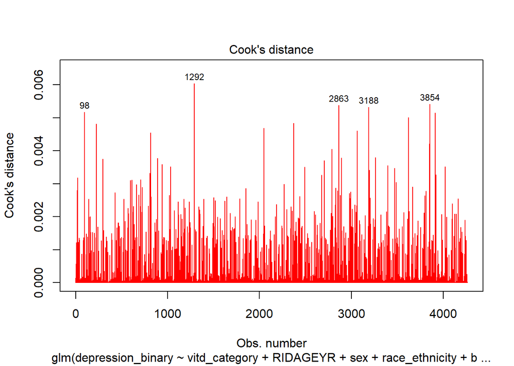

```r
# Plot Cook's Distance to identify influential observations
plot(model_adjusted, which = 4, id.n = 5, col = "red")

# Reference line at Cook's D = 1
abline(h = 1, lty = 2, col = "blue")
```

# 13. Model Performance Evaluation

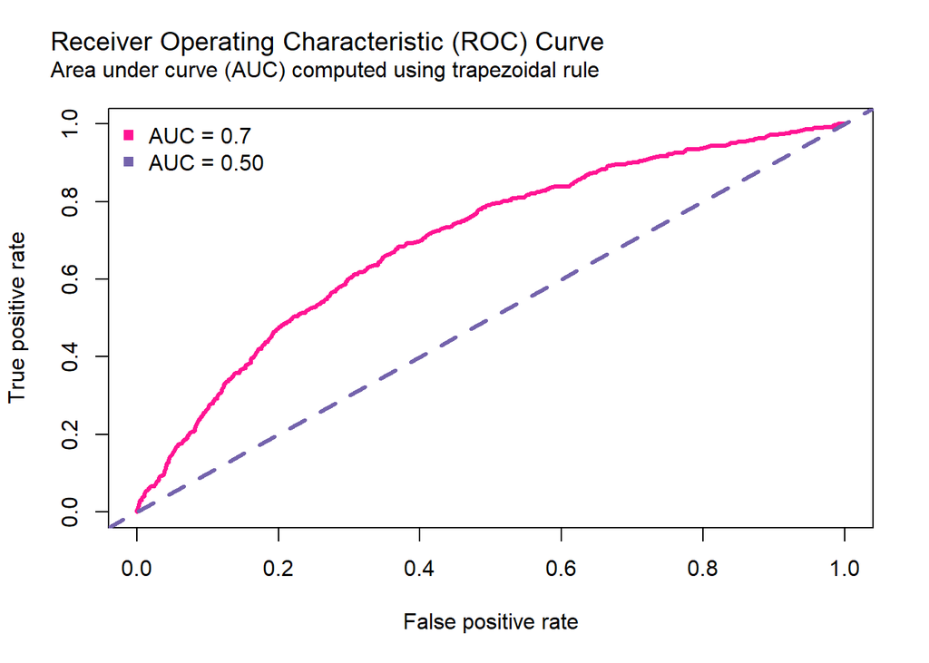

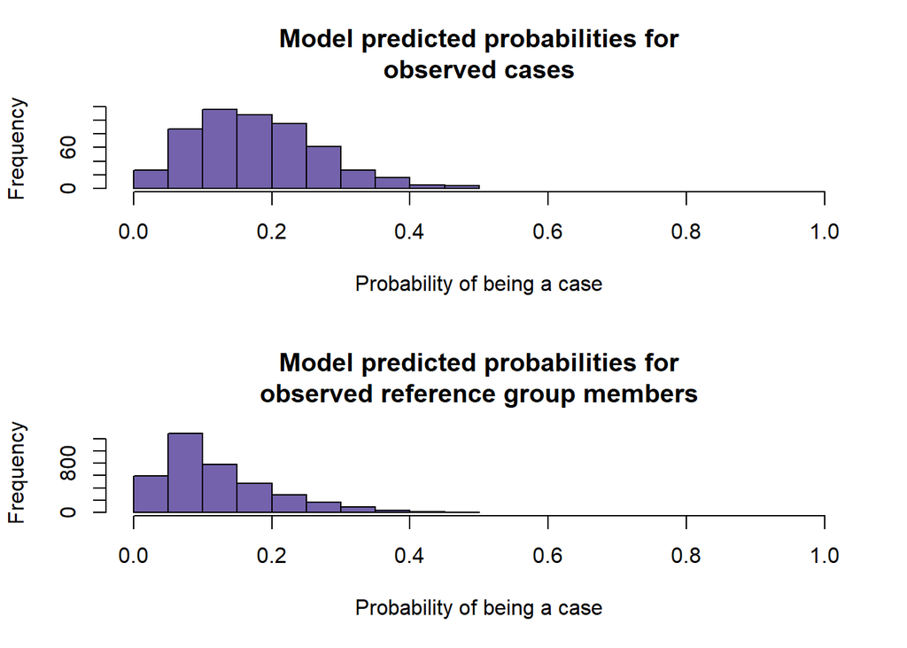

```
## $`Logistic regression model significance`
## Chi-squared        d.f.           p
##     238.634          17       <.001
##
## $`Contingency tables (model fit): frequency predicted`
##                 Number observed
## Number predicted    1    0  Sum
##              1      0    0    0
##              0    546 3716 4262
##              Sum  546 3716 4262
##
## $`Count R-squared (model fit): percent correctly predicted`
## [1] 87.18911
##
## $`Model sensitivity`
## [1] 0
##
## $`Model specificity`
## [1] 1
##
## $`Predictor odds ratios and 95% CI`
##                                           OR     2.5 %    97.5 %
## (Intercept)                        0.4898002 0.2490597 0.9428569
## vitd_categoryInsufficient          1.1972560 0.9501450 1.5054773
## vitd_categoryDeficient             1.2968224 0.9956888 1.6837790
## RIDAGEYR                           0.9828013 0.9769159 0.9887006
## sexFemale                          1.4157432 1.1644382 1.7247498
## race_ethnicityNon-Hispanic Asian   0.9063957 0.4503013 1.7389947
## race_ethnicityNon-Hispanic Black   1.0158630 0.6468073 1.6116048
## race_ethnicityNon-Hispanic White   1.4149671 0.9633322 2.1240959
## race_ethnicityOther Hispanic       1.0951884 0.6965546 1.7360527
## race_ethnicityOther/Multiracial    1.5352229 0.9449786 2.5090548
## bmi_catOverweight                  0.9570923 0.7410508 1.2375269
## bmi_catObese                       1.1751040 0.9298889 1.4904293
## education9-11th grade              0.8550420 0.5051378 1.4718499
## educationHigh school/GED           0.7805717 0.4817699 1.2963102
## educationSome college/AA           0.8139757 0.5057240 1.3446744
## educationCollege graduate or above 0.5894671 0.3548788 1.0016870
## INDFMPIR                           0.7550167 0.7042440 0.8088859
## smoking_statusEver smoker          1.3827287 1.1341145 1.6862643
```

```r
# Evaluate model fit with predicted probabilities, ROC curve, and AUC
odds.n.ends(model_adjusted, predProbPlot = TRUE, rocPlot = TRUE)
```

# 14. Table 1: Baseline Characteristics (following class exercise pattern)

|  | No Depression (N=3716) | Depression (N=546) | Overall (N=4262) |
| --- | --- | --- | --- |
| Serum Vitamin D (nmol/L) |  |  |  |
| Mean (SD) | 84.1 (37.6) | 74.7 (37.7) | 82.9 (37.7) |
| Median [Min, Max] | 79.8 [9.13, 424] | 70.0 [11.2, 239] | 78.4 [9.13, 424] |
| Vitamin D Status |  |  |  |
| Sufficient | 2082 (56.0%) | 242 (44.3%) | 2324 (54.5%) |
| Insufficient | 978 (26.3%) | 166 (30.4%) | 1144 (26.8%) |
| Deficient | 656 (17.7%) | 138 (25.3%) | 794 (18.6%) |
| Age (years) |  |  |  |
| Mean (SD) | 54.6 (16.7) | 49.5 (17.3) | 54.0 (16.8) |
| Median [Min, Max] | 59.0 [20.0, 80.0] | 51.0 [20.0, 80.0] | 58.0 [20.0, 80.0] |
| Sex |  |  |  |
| Male | 1723 (46.4%) | 205 (37.5%) | 1928 (45.2%) |
| Female | 1993 (53.6%) | 341 (62.5%) | 2334 (54.8%) |
| Race/Ethnicity |  |  |  |
| Mexican American | 227 (6.1%) | 39 (7.1%) | 266 (6.2%) |
| Non-Hispanic Asian | 174 (4.7%) | 14 (2.6%) | 188 (4.4%) |
| Non-Hispanic Black | 379 (10.2%) | 63 (11.5%) | 442 (10.4%) |
| Non-Hispanic White | 2376 (63.9%) | 325 (59.5%) | 2701 (63.4%) |
| Other Hispanic | 338 (9.1%) | 56 (10.3%) | 394 (9.2%) |
| Other/Multiracial | 222 (6.0%) | 49 (9.0%) | 271 (6.4%) |
| BMI Category |  |  |  |
| Normal/Underweight | 986 (26.5%) | 133 (24.4%) | 1119 (26.3%) |
| Overweight | 1232 (33.2%) | 154 (28.2%) | 1386 (32.5%) |
| Obese | 1498 (40.3%) | 259 (47.4%) | 1757 (41.2%) |
| Education Level |  |  |  |
| Less than 9th grade | 111 (3.0%) | 27 (4.9%) | 138 (3.2%) |
| 9-11th grade | 241 (6.5%) | 57 (10.4%) | 298 (7.0%) |
| High school/GED | 702 (18.9%) | 131 (24.0%) | 833 (19.5%) |
| Some college/AA | 1115 (30.0%) | 201 (36.8%) | 1316 (30.9%) |
| College graduate or above | 1547 (41.6%) | 130 (23.8%) | 1677 (39.3%) |
| Income-to-Poverty Ratio |  |  |  |
| Mean (SD) | 3.18 (1.62) | 2.25 (1.54) | 3.06 (1.64) |
| Median [Min, Max] | 3.28 [0, 5.00] | 1.82 [0, 5.00] | 3.04 [0, 5.00] |
| Smoking Status |  |  |  |
| Never smoker | 2221 (59.8%) | 269 (49.3%) | 2490 (58.4%) |
| Ever smoker | 1495 (40.2%) | 277 (50.7%) | 1772 (41.6%) |

**Table 1.** Baseline characteristics stratified by depression status (PHQ-9 ≥ 10). Continuous variables presented as mean ± SD; categorical variables as N (%).

# 8. Figure 1: Participant Selection Flowchart (following class exercise pattern)

[interactive chart not shown]

**Figure 1.** Participant selection flowchart for NHANES 2021-2023 analysis of vitamin D and depression.

*Covariates: sex, race/ethnicity, BMI, education, income-to-poverty ratio, smoking status

#**Inclusion Criteria:** #- Adults aged ≥18 years # Complete serum vitamin D measurements (LBXVIDMS) #- Complete PHQ-9 depression assessment #- Complete data on all covariates (sex, race/ethnicity, BMI, education, income-to-poverty ratio, smoking status)

#**Exclusion Criteria:** #- Age <18 years #- Missing vitamin D measurements #- Missing PHQ-9 data #- Missing covariate data